# Pertemuan 2 - Regresi Soal 1

Naurah Aathirah Farid

# Pemanggilan *Packages*

```r
library(dplyr)
library(TTR)
library(forecast)
library(lmtest) #digunakan untuk uji formal pendeteksian autokorelasi
library(orcutt) #untuk membuat model regresi Cochrane-Orcutt
library(HoRM) #untuk membuat model regresi Hildreth-Lu
```

# Input Data

Data yang digunakan dalam kesempatan kali ini adalah data Market Share (Y) sebagai peubah respon dan Price (X) sebagai peubah penjelas sebanyak 20 periode pengamatan.

```r
period <- 1:20
marketshare <- c(3.63,4.20,3.33,4.54,2.89,4.87,4.90,5.29,6.18,7.20,7.25,6.09,6.80,8.65,8.43,8.29,7.18,7.90,8.45,8.23)
price <- c(0.97,0.95,0.99,0.91,0.98,0.90,0.89,0.86,0.85,0.82,0.79,0.83,0.81,0.77,0.76,0.80,0.83,0.79,0.76,0.78)
dtmarket <- cbind(period,marketshare,price)
dtmarket <- as.data.frame(dtmarket)
dtmarket
```

```
##    period marketshare price
## 1       1        3.63  0.97
## 2       2        4.20  0.95
## 3       3        3.33  0.99
## 4       4        4.54  0.91
## 5       5        2.89  0.98
## 6       6        4.87  0.90
## 7       7        4.90  0.89
## 8       8        5.29  0.86
## 9       9        6.18  0.85
## 10     10        7.20  0.82
## 11     11        7.25  0.79
## 12     12        6.09  0.83
## 13     13        6.80  0.81
## 14     14        8.65  0.77
## 15     15        8.43  0.76
## 16     16        8.29  0.80
## 17     17        7.18  0.83
## 18     18        7.90  0.79
## 19     19        8.45  0.76
## 20     20        8.23  0.78
```

# Eksplorasi Data

Sebelum melakukan regresi, akan diperlihatkan *plot time-series* dari peubah Market Share Periode 1-20.

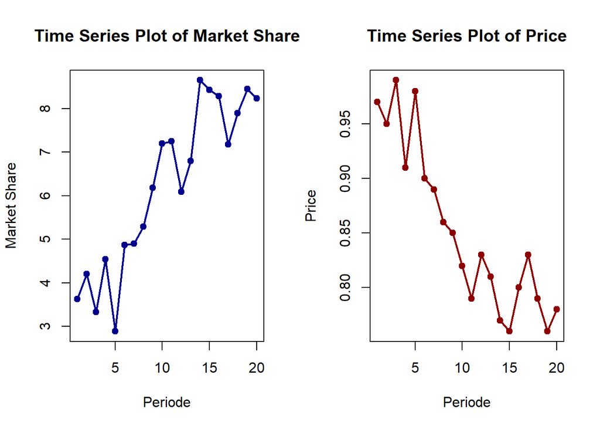

```r
# Membentuk objek time series
marketshare.ts <- ts(dtmarket$marketshare)
price.ts <- ts(dtmarket$price)

# Plot time series masing-masing peubah
par(mfrow = c(1, 2))
ts.plot(marketshare.ts, xlab = "Periode", ylab = "Market Share",
        main = "Time Series Plot of Market Share", col = "darkblue", lwd = 2)
points(marketshare.ts, pch = 19, col = "darkblue")

ts.plot(price.ts, xlab = "Periode", ylab = "Price",
        main = "Time Series Plot of Price", col = "darkred", lwd = 2)
points(price.ts, pch = 19, col = "darkred")
```

Berdasarkan plot time series di atas, terlihat peubah Market Share menunjukkan pola tren yang cenderung meningkat seiring bertambahnya waktu, sedangkan Price menunjukkan pola tren yang menurun.

# Hubungan Antar Peubah (Scatter Plot & Korelasi)

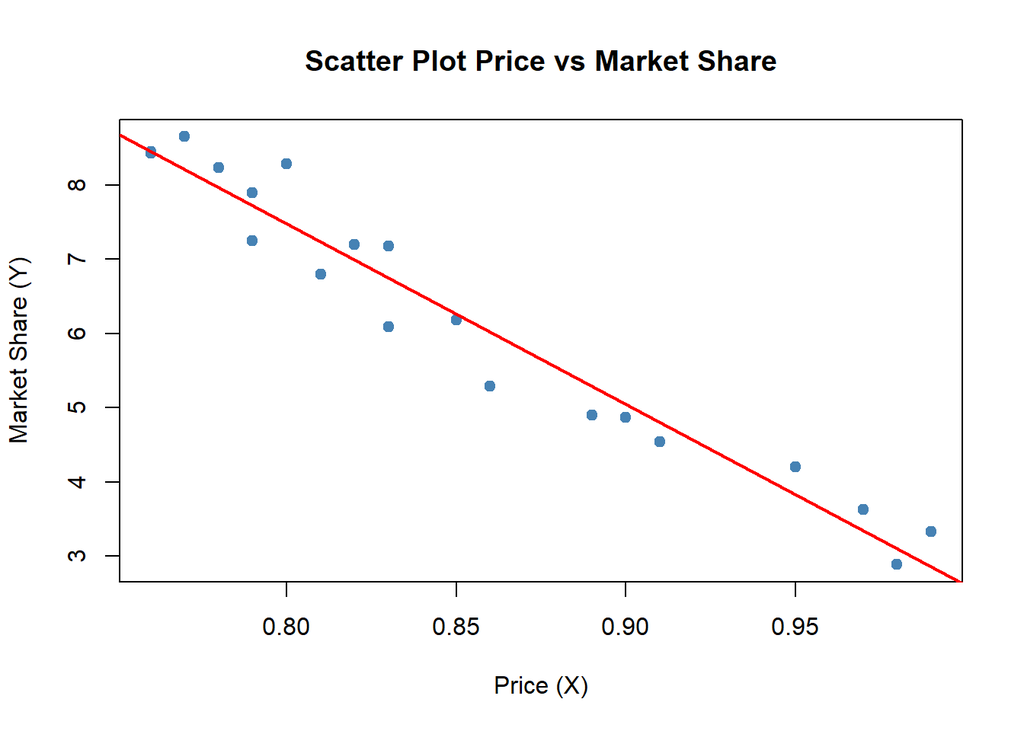

```r
par(mfrow = c(1, 1))
# Scatter Plot
plot(dtmarket$price, dtmarket$marketshare, pch = 19, col = "steelblue",
     main = "Scatter Plot Price vs Market Share",
     xlab = "Price (X)",
     ylab = "Market Share (Y)")
abline(lm(marketshare ~ price, data = dtmarket), col = "red", lwd = 2)
```

```r
# Korelasi Pearson
korelasi <- cor(dtmarket$price, dtmarket$marketshare)
korelasi
```

```
## [1] -0.9752564
```

Berdasarkan scatterplot dan perhitungan korelasi Pearson diperoleh nilai korelaso sebesar -0.9752564. Hal ini menunjukkan bahwa adanya hubungan linier yang negatif dan sangat kuat.

# Pemodelan Regresi OLS

```r
model <- lm(marketshare ~ price, data = dtmarket)
summary(model)
```

```
##
## Call:
## lm(formula = marketshare ~ price, data = dtmarket)
##
## Residuals:
##      Min       1Q   Median       3Q      Max
## -0.73068 -0.29764 -0.00966  0.30224  0.81193
##
## Coefficients:
##             Estimate Std. Error t value Pr(>|t|)
## (Intercept)   26.910      1.110   24.25 3.39e-15 ***
## price        -24.290      1.298  -18.72 3.02e-13 ***
## ---
## Signif. codes:  0 '***' 0.001 '**' 0.01 '*' 0.05 '.' 0.1 ' ' 1
##
## Residual standard error: 0.4287 on 18 degrees of freedom
## Multiple R-squared:  0.9511, Adjusted R-squared:  0.9484
## F-statistic: 350.3 on 1 and 18 DF,  p-value: 3.019e-13
```

Berdasarkan ringkasan model dapat diketahui bahwa hasil uji F memiliki p-value < $\alpha$ (5%). Artinya, minimal terdapat satu variabel yang berpengaruh nyata terhadap model. Hasil uji-t parsial kedua parameter regresi, yaitu intersep dan koefisien regresi juga menunjukkan hal yang sama, yaitu memiliki p-value < $\alpha$ (5%) sehingga nyata dalam taraf 5%. Selanjutnya dapat dilihat juga nilai $R^2 = 0.9511$. Artinya, sebesar 95.11% keragaman nilai market share dapat dijelaskan oleh peubah price. Hasil ini menunjukkan hasil yang bagus, seolah mendapatkan hasil terbaik. Namun, kita perlu melakukan uji terhadap sisaannya seperti berikut ini.

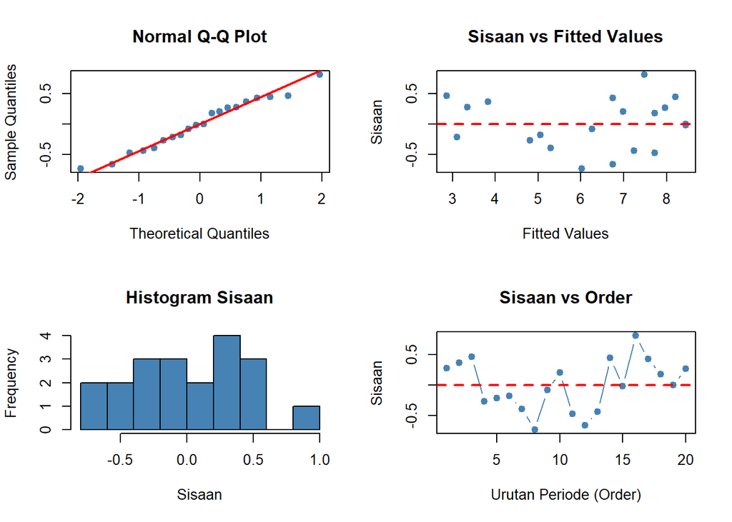

```r
sisaan <- residuals(model)
fitValue <- predict(model)

par(mfrow = c(2, 2))

# 1. Normal Q-Q Plot
qqnorm(sisaan, col = "steelblue", pch = 19)
qqline(sisaan, col = "red", lwd = 2)

# 2. Sisaan vs Fitted Values
plot(fitValue, sisaan, col = "steelblue", pch = 19,
     xlab = "Fitted Values", ylab = "Sisaan", main = "Sisaan vs Fitted Values")
abline(h = 0, col = "red", lwd = 2, lty = 2)

# 3. Histogram Sisaan
hist(sisaan, col = "steelblue", main = "Histogram Sisaan", xlab = "Sisaan")

# 4. Sisaan vs Order (Waktu)
plot(dtmarket$period, sisaan, col = "steelblue", pch = 19, type = "b",
     xlab = "Urutan Periode (Order)", ylab = "Sisaan", main = "Sisaan vs Order")
abline(h = 0, col = "red", lwd = 2, lty = 2)
```

# Diagnostik Sisaan & Uji Asumsi Klasik

## Eksplorasi Visual Sisaan

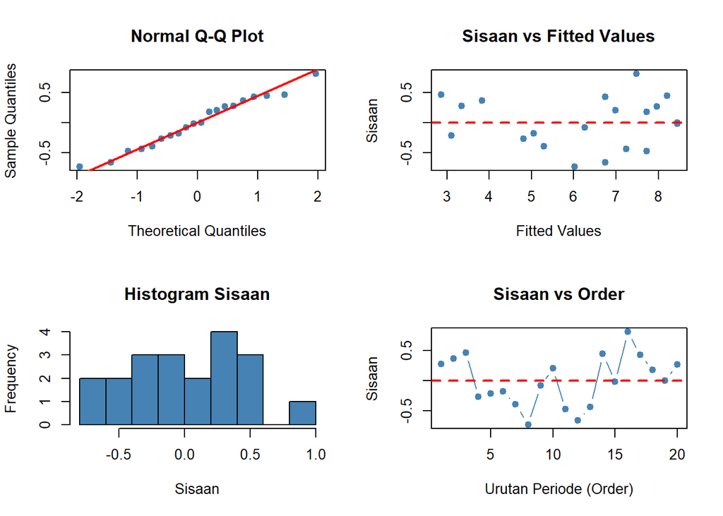

```r
sisaan <- residuals(model)
fitValue <- predict(model)

par(mfrow = c(2, 2))

# 1. Normal Q-Q Plot
qqnorm(sisaan, col = "steelblue", pch = 19)
qqline(sisaan, col = "red", lwd = 2)

# 2. Sisaan vs Fitted Values
plot(fitValue, sisaan, col = "steelblue", pch = 19,
     xlab = "Fitted Values", ylab = "Sisaan", main = "Sisaan vs Fitted Values")
abline(h = 0, col = "red", lwd = 2, lty = 2)

# 3. Histogram Sisaan
hist(sisaan, col = "steelblue", main = "Histogram Sisaan", xlab = "Sisaan")

# 4. Sisaan vs Order (Waktu)
plot(dtmarket$period, sisaan, col = "steelblue", pch = 19, type = "b",
     xlab = "Urutan Periode (Order)", ylab = "Sisaan", main = "Sisaan vs Order")
abline(h = 0, col = "red", lwd = 2, lty = 2)
```

Pada plot Sisaan vs Order, terlihat titik-titik sisaan membentuk pola sistematis/bergelombang dan tidak tersebar secara acak di sekitar sumbu nol, yang mengindikasikan adanya autokorelasi pada sisaan.

# Uji Normalitas Sisaan

```r
# H0: Sisaan menyebar normal
# H1: Sisaan tidak menyebar normal
shapiro.test(sisaan)
```

```
##
##  Shapiro-Wilk normality test
##
## data:  sisaan
## W = 0.9744, p-value = 0.8437
```

```r
ks.test(sisaan, "pnorm", mean = mean(sisaan), sd = sd(sisaan))
```

```
##
##  Exact one-sample Kolmogorov-Smirnov test
##
## data:  sisaan
## D = 0.11606, p-value = 0.9222
## alternative hypothesis: two-sided
```

Berdasarkan uji formal Saphiro-Wilk dan Kolmogorov-Smirnov didapatkan nilai *p-value* > $\alpha$ (5%). Artinya, cukup bukti untuk menyatakan sisaan berdistribusi normal.